# Statistics in Action - case study 1

Toxicity assessment of the MON810 maize

```r
if (!require("pacman")) install.packages("pacman")
```

```r
pacman::p_load(dplyr, ggplot2)
```

# 1 Introduction

The dataset dataMON810_2018.csv consists of several measurements made during a subchronic toxicity study concerning the MON810 maize.

Biochemical parameters reflecting most physiological functions were measured two times (week 5 and 14), in particular through serum and urine chemistry, and hematology. Organ weights were measured at week 14.

The main objective of this study is to evaluate possible GMO effects on these parameters.

# 2 Single comparison

1. We consider the variable “CALCIUM”. First we load the data and omit the missing observation

```r
data.study <- read.csv('/Users/Daniel/Documents/Courses X/Statistics in Action/Homework 1/dataMON810_2018.csv')

#data.study <- read.csv('https://github.com/daniel-wientjens/Stats-in-Action-Homework-1/blob/master/dataMON810_2018.csv')
```

1. test if the mean level of calcium for period 2 is the same for males and females.  
   **Hint:** plot first the data and justify the test(s) to use.

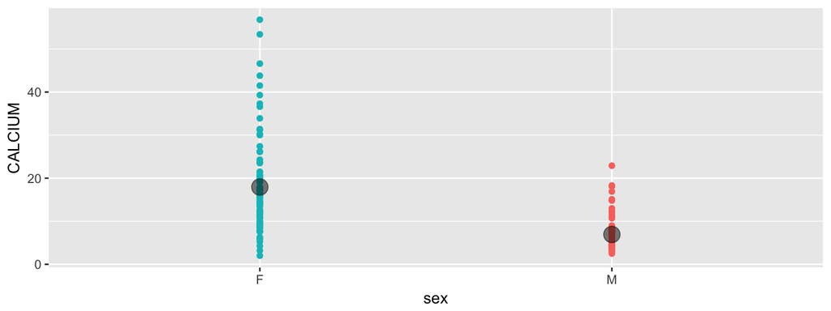

```r
#Splitting the dataset into the two periods
data.study.p1 <- data.study %>% filter(period == 1)
data.study.p2 <- data.study %>% filter(period == 2)

#Splitting the dataset of period 2 into male and female and plotting the result
data.study.p2.m <- data.study.p2 %>% filter(sex == 'M')
data.study.p2.f <- data.study.p2 %>% filter(sex == 'F')

new <- aggregate(data.study.p2$CALCIUM ~ data.study.p2$sex, FUN= "mean")
colnames(new) <- c('sex', 'calcium')

ggplot()+
  geom_point(data = data.study.p2.m, aes(x=sex, y=CALCIUM, colour = 'blue'), show.legend = F) +
  geom_point(data = data.study.p2.f, aes(x=sex, y=CALCIUM, colour = 'red'), show.legend = F) +
  geom_point(data = new, aes(x=sex, y=calcium), size=5, alpha=0.5)
```

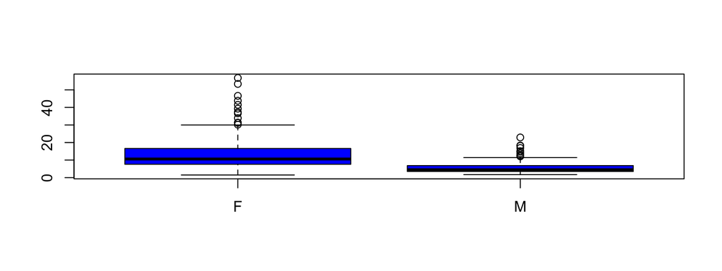

```r
boxplot(CALCIUM ~ sex, data = data.study, col = "blue")
```

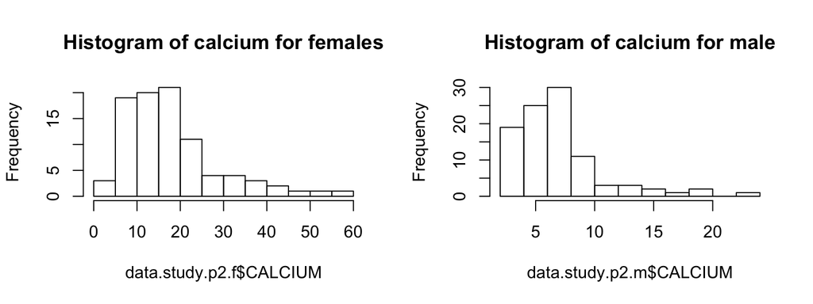

```r
par(mfrow = c(1, 2))
hist(data.study.p2.f$CALCIUM, main='Histogram of calcium for females')
hist(data.study.p2.m$CALCIUM, main='Histogram of calcium for male')
```

As we can see the variances are different, while we want to check whether the means of males and females differ.

```r
aggregate(data.study.p2$CALCIUM ~ data.study.p2$sex, FUN= "sd" )
```

```
##   data.study.p2$sex data.study.p2$CALCIUM
## 1                 F             10.823363
## 2                 M              3.636859
```

```r
aggregate(data.study.p2$CALCIUM ~ data.study.p2$sex, FUN= "mean" )
```

```
##   data.study.p2$sex data.study.p2$CALCIUM
## 1                 F             17.943333
## 2                 M              6.930928
```

```r
alpha<-0.05

x <- data.study[data.study$sex=="M","CALCIUM"]
y <- data.study[data.study$sex=="F","CALCIUM"]
var.test(x,y, alternative = 'two.sided')
```

```
##
##  F test to compare two variances
##
## data:  x and y
## F = 0.11536, num df = 194, denom df = 186, p-value < 2.2e-16
## alternative hypothesis: true ratio of variances is not equal to 1
## 95 percent confidence interval:
##  0.08668978 0.15338281
## sample estimates:
## ratio of variances
##          0.1153615
```

```r
#as we can see here the F-test shows us that the variances of the two populations are not equal
t.test(x,y, conf.level=1-alpha, var.equal = FALSE)
```

```
##
##  Welch Two Sample t-test
##
## data:  x and y
## t = -10.972, df = 226.77, p-value < 2.2e-16
## alternative hypothesis: true difference in means is not equal to 0
## 95 percent confidence interval:
##  -9.308409 -6.474079
## sample estimates:
## mean of x mean of y
##  5.532821 13.424064
```

```
 b. test for the males if the mean level of calcium is the same for period 1 and period 2.
```

```r
x <- data.study %>% filter(sex == 'M', period == '1') %>% select('CALCIUM', 'sex')
y <- data.study %>% filter(sex == 'M', period == '2') %>% select('CALCIUM', 'sex')

aggregate(x$CALCIUM ~ x$sex, FUN= "sd" )
```

```
##   x$sex x$CALCIUM
## 1     M  1.764615
```

```r
aggregate(y$CALCIUM ~ y$sex, FUN= "sd" )
```

```
##   y$sex y$CALCIUM
## 1     M  3.636859
```

```r
var.test(x$CALCIUM,y$CALCIUM, alternative = 'two.sided')
```

```
##
##  F test to compare two variances
##
## data:  x$CALCIUM and y$CALCIUM
## F = 0.23542, num df = 97, denom df = 96, p-value = 9.271e-12
## alternative hypothesis: true ratio of variances is not equal to 1
## 95 percent confidence interval:
##  0.1575523 0.3516297
## sample estimates:
## ratio of variances
##          0.2354219
```

```r
#as we can see here the F-test shows us that the variances of the two populations are not equal

t.test(x$CALCIUM,y$CALCIUM, conf.level = 1-alpha, var.equal = FALSE)
```

```
##
##  Welch Two Sample t-test
##
## data:  x$CALCIUM and y$CALCIUM
## t = -6.7846, df = 138.51, p-value = 3.113e-10
## alternative hypothesis: true difference in means is not equal to 0
## 95 percent confidence interval:
##  -3.592694 -1.971202
## sample estimates:
## mean of x mean of y
##  4.148980  6.930928
```

```
 c. test for the males if the mean level of calcium for period 2 is the same for the control group and the MON810 group.
```

```r
data.study.cont <- data.study %>% filter(sex == 'M',regimen == 'control')
data.study.MON810 <- data.study %>% filter(sex == 'M',regimen == 'MON810')
var.test(data.study.cont$CALCIUM, data.study.MON810$CALCIUM,conf.level = 1-alpha, var.equal = FALSE)
```

```
##
##  F test to compare two variances
##
## data:  data.study.cont$CALCIUM and data.study.MON810$CALCIUM
## F = 0.482, num df = 39, denom df = 38, p-value = 0.02574
## alternative hypothesis: true ratio of variances is not equal to 1
## 95 percent confidence interval:
##  0.2534947 0.9140280
## sample estimates:
## ratio of variances
##          0.4820026
```

```r
t.test(data.study.cont$CALCIUM, data.study.MON810$CALCIUM, conf.level = 1-alpha)
```

```
##
##  Welch Two Sample t-test
##
## data:  data.study.cont$CALCIUM and data.study.MON810$CALCIUM
## t = -0.5484, df = 67.569, p-value = 0.5852
## alternative hypothesis: true difference in means is not equal to 0
## 95 percent confidence interval:
##  -1.7274801  0.9827365
## sample estimates:
## mean of x mean of y
##  5.322500  5.694872
```

4. What is the probability to detect a difference of 1 sd (one standard deviation) with only 10 animals per group? with 20 animal? How can we ensure to detect such difference with a probability of 80%?

```r
#std.er <- sqrt((std.er(data.study.cont$CALCIUM)/10)+(std.er(data.study.MON810$CALCIUM)/10))
```

```
 e. Test for the males if the mean levels of calcium for period 2 of the control group and the MON810 are equivalent. The equivalence limits will be defined using the 6 reference groups as *i)* one standard deviation of the 6 reference means, *ii)* two standard deviations of the 6 reference means.

 f. Summarize and comment these results.
```

2. Do the same analysis with the variable “DIRBILI” (direct bilirubin)

# 3 Multiple comparisons

1. Redo the three tests of the previous section (questions a., b. and c.) for now comparing the means of all the quantitative variables (see the annex 5 of the ANSES report BIOT2009sa0285Ra.pdf to know the type of each variable). Store the results (i.e. all the p-values) in a dataframe with one variable per row and four columns (name of the variable + three p-values).
2. For each of the three tests, adjust the p-values using the Bonferroni and the Benjamini-Hochberg corrections. How can we interpret these results?